# **Survey Results**

- **Mode of communication**: Unanimously Email
- **Programming proficiency**: Mostly beginners (expected)
- **after-lesson commitment**: very diverse answers
- **Preferred Learning styles**: Demonstration & Collaboration
- **Interests**: ...

```
building a website                    3
building a 2D computer game           3
analyse data / machine learning       5
write some scripts to manage files    2
automate boring stuff                 1
dtype: int64
```

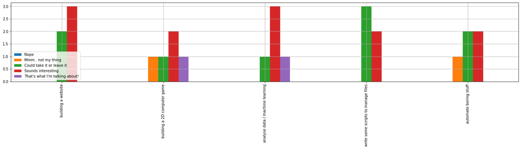

```python
# DON'T WORRY IF YOU DON'T UNDERSTAND THIS CODE JUST YET
# IT'S ONLY TO PLOT THE RESULT OF THE SURVEY

import pandas as pd
%matplotlib inline

df = pd.DataFrame({
    'Nope':                           [0,0,0,0,0],
    'Mmm.. not my thing':             [0,1,0,0,1],
    'Could take it or leave it':      [2,1,1,3,2],
    'Sounds interesting':             [3,2,3,2,2],
    "That's what I'm talking about!": [0,1,1,0,0],
}, index=['building a website', 'building a 2D computer game', 'analyse data / machine learning', 'write some scripts to manage files', 'automate boring stuff'])

df.plot.bar(figsize=(25,4), grid=True).legend(loc=3)

weights = [-2,-1,0,1,2]
activity_scores = (df*weights).sum(axis=1)
display(activity_scores)

# RESULT: data analysis for the WIN! :)
```

# Home Work (**NO CLASS ON THE 23RD!**)

During these 2 weeks, find dataset(s) that interest you, so we can analyse them.

Don't know where to start?

- https://www.quora.com/What-are-some-interesting-data-sets-available-out-there
- https://statistics.gov.scot/home
- https://www.dataquest.io/blog/free-datasets-for-projects/
- .. or something you work with (and is anonymised enough)

# Basics Overview continues..

- **Aggregate Types**
  - lists (sequence of items)
  - tuples (immutable lists)
  - dictionaries (key-value pairs)
- **Flow Control**
  - if.. elif.. else.. (Conditionals)
  - for i in seq (For Loop)
  - while i > 0 (While Loop)
- **Functions**
  - def myfunc(a, b, c=0)
- **Classes**
  - class MyClass

## **Lists**

editable (mutable) sequence of items

```python
my_wierd_list = ['Jim', 3, False, [1,2]]  # each element can be a different type

my_list = ['John', 'Paul', 'George', 'Ringo']  # most common is all the same type
```

```python
# get first item
my_list[0]
```

```
'John'
```

```python
#get last item
my_list[-1]
```

```
'Ringo'
```

```python
# get second item?
...
```

```python
# get second-to-last item?
...
```

### *List slicing*

also used for **arrays**, **matrices**, **pd.Series** and **strings**

### *LIST[start:end:step]*

[figure not shown]

```python
# taking first two
my_list[:2]    # same as my_list[0:2:1]
```

```
['John', 'Paul']
```

```python
# taking last two
my_list[-2:]    # same as my_list[-2::1]
```

```
['George', 'Ringo']
```

```python
# taking middle two?
...
```

```python
# taking one every two (even numbers)
my_list[::2]
```

```
['John', 'George']
```

```python
# reversing the order?
...
```

```python
# sorting a list
sorted(my_list)
```

```
['George', 'John', 'Paul', 'Ringo']
```

```python
# changing one value
print('before: ', my_list)
my_list[2] = 'THE George'
print('after: ', my_list)
```

```
before:  ['John', 'Paul', 'George', 'Ringo']
after:  ['John', 'Paul', 'THE George', 'Ringo']
```

```python
# adding elements to a list
my_list.append('Pete')

my_list
```

```
['John', 'Paul', 'THE George', 'Ringo', 'Pete']
```

```python
# checking if element in list
'Pete' in my_list
```

```
True
```

## **Tuples** (very briefly)

basically lists that cannot be edited (immutable)

```python
my_tuple = ('John', 'Paul', 'George', 'Ringo')  # most common is all the same type

sorted(my_tuple[-2:])
```

```
['George', 'Ringo']
```

```python
my_tuple.append(42)  # won't work
```

```
---------------------------------------------------------------------------
AttributeError                            Traceback (most recent call last)
<ipython-input-17-1633a8bf04b2> in <module>
----> 1 my_tuple.append(42)  # won't work

AttributeError: 'tuple' object has no attribute 'append'
```

```python
my_tuple[2] = 'THE George'  # won't work
```

```
---------------------------------------------------------------------------
TypeError                                 Traceback (most recent call last)
<ipython-input-18-cf84bf8e4fd8> in <module>
----> 1 my_tuple[2] = 'THE George'  # won't work

TypeError: 'tuple' object does not support item assignment
```

## **Dictionaries**

Collection of key-value pairs

```python
the_beatles_instruments = {
    'John': ['vocals', 'rhythm and lead guitar', 'keyboards', 'harmonica', 'bass guitar'],
    'Paul':  ['vocals', 'bass guitar', 'rhythm and lead guitar', 'keyboards', 'drums'],
    'George': ['lead and rhythm guitar', 'vocals', 'sitar', 'keyboards', 'bass guitar'],
    'Ringo': ['drums', 'percussion', 'vocals'],
}

the_beatles_tenure = {
    'John': {'start': 1960, 'end': 1969},
    'Paul':  [1960, 1970],
    'George': (1960, 1970),
    'Ringo': '1962–1970',
}
```

```python
# accessing a value
the_beatles_instruments['Paul']
```

```
['vocals', 'bass guitar', 'rhythm and lead guitar', 'keyboards', 'drums']
```

```python
# starting year of John?
...
```

```python
# adding a new value
the_beatles_instruments['Pete'] = ['drums']

the_beatles_instruments
```

```
{'John': ['vocals',
  'rhythm and lead guitar',
  'keyboards',
  'harmonica',
  'bass guitar'],
 'Paul': ['vocals',
  'bass guitar',
  'rhythm and lead guitar',
  'keyboards',
  'drums'],
 'George': ['lead and rhythm guitar',
  'vocals',
  'sitar',
  'keyboards',
  'bass guitar'],
 'Ringo': ['drums', 'percussion', 'vocals'],
 'Pete': ['drums']}
```

```python
# getting all keys
the_beatles_tenure.keys()
```

```
dict_keys(['John', 'Paul', 'George', 'Ringo'])
```

```python
# getting all values
the_beatles_tenure.values()
```

```
dict_values([{'start': 1960, 'end': 1969}, [1960, 1970], (1960, 1970), '1962–1970'])
```

```python
# getting all keys-values as pairs
the_beatles_tenure.items()
```

```
dict_items([('John', {'start': 1960, 'end': 1969}), ('Paul', [1960, 1970]), ('George', (1960, 1970)), ('Ringo', '1962–1970')])
```

## **If Statement**

diverting the execution flow depending on 1+ condition

```python
happy = True
know_it = True
```

```python
if happy == True and know_it == True:
    print('hands go clap clap')
elif know_it == False:
    print('hands go clap')
else:
    print('...silence...')
```

```
hands go clap clap
```

```python
# what result do I expect with.. ?
happy = True
know_it = False
```

```python
# what result do I expect with.. ?
happy = False
know_it = True
```

```python
# what result do I expect with.. ?
happy = False
know_it = False
```

## **For Loop**

runs a part of the code multiple times: one for every item in the sequence

```python
for i in range(5):
    print(i)
```

```
0
1
2
3
4
```

```python
d = {1: 'one', 4:'four'}

for k in d.items():
    print('pair:', k)
```

```
pair: (1, 'one')
pair: (4, 'four')
```

```python
for k,v in d.items():
    print('key:', k, 'value:', v)
```

```
key: 1 value: one
key: 4 value: four
```

```python
print(the_beatles_instruments)
```

```
{'John': ['vocals', 'rhythm and lead guitar', 'keyboards', 'harmonica', 'bass guitar'], 'Paul': ['vocals', 'bass guitar', 'rhythm and lead guitar', 'keyboards', 'drums'], 'George': ['lead and rhythm guitar', 'vocals', 'sitar', 'keyboards', 'bass guitar'], 'Ringo': ['drums', 'percussion', 'vocals'], …
```

```python
# NESTED LOOP
# I heard you like loops so I put a loop in a loop...
for member, instruments in the_beatles_instruments.items():
    for instrument in instruments:
        print(member, 'plays', instrument)
```

```
John plays vocals
John plays rhythm and lead guitar
John plays keyboards
John plays harmonica
John plays bass guitar
Paul plays vocals
Paul plays bass guitar
Paul plays rhythm and lead guitar
Paul plays keyboards
Paul plays drums
George plays lead and rhythm guitar
George plays vocals
George plays sitar
George plays keyboards
George plays bass guitar
Ringo plays drums
Ringo plays percussion
Ringo plays vocals
Pete plays drums
```

## **While Loop**

runs a part of the code multiple times: until a condition is met

```python
current_value = 0
while current_value <= 5:
    print('the current value is: ', current_value)
    current_value += 1
```

```
the current value is:  0
the current value is:  1
the current value is:  2
the current value is:  3
the current value is:  4
the current value is:  5
```

## **Function**

ways to group and reuse code that can be logically isolated

```python
# defining a function
def simple_greeting():
    print('Hi')
```

```python
# calling a function (using it)
simple_greeting()
```

```
Hi
```

```python
def greeting(name):
    print('Hi,', name)

greeting('Bob')        # passing argument as positional
greeting(name='Bob')   # passing argument as keyword
```

```
Hi, Bob
Hi, Bob
```

```python
def greeting_with_default(name='you'):
    print('Hi,', name)

greeting_with_default()
greeting_with_default('Bob')
greeting_with_default(name='Bob')
```

```
Hi, you
Hi, Bob
Hi, Bob
```

```python
# returning values instead of printing it
def duplicate(x):
    return 2*x

douplex = duplicate(3)
douplex
```

```
6
```

```python
# what happens if I do.. ?
duplicate(duplicate(3))
```

```
12
```

## **Classes**

Classes provide a means of bundling data and functionality together. Creating a new class creates a new type of object, allowing new instances of that type to be made. Each class instance can have attributes attached to it for maintaining its state. Class instances can also have methods (defined by its class) for modifying its state.

```python
# defining the class
class Dog:
    def __init__(self, name):
        self.name = name
        self.tricks = []

    def add_trick(self, trick):
        self.tricks.append(trick)

# Don't worry if you don't fully understand the above, focus on the below :)

# creating and using an instance of it
d = Dog('Fido')
d.add_trick('roll over')
d.add_trick('play dead')
d.tricks
```

```
['roll over', 'play dead']
```

## **Revisited High-Low**

using what we have learned so far..

`input(message)` is a built-in python function that requests user input showing a message

```python
import random

CARDS = range(1, 13+1)
card = random.choice(CARDS)

def ask_guess(card):
    print('====================')
    print('The current card is', card)
    guess = input('Is the next one going to be higher ("h") or lower ("l")? ("q" to quit)')
    return guess

def evaluate_result(card, new_card, guess):
    if new_card == card:
        print('They are exactly the same card, you lose :(')
    elif (new_card > card and guess == 'h') or (new_card < card and guess == 'l'):
        print('Well done! you guessed correcty :)')
    else:
        print('Wrong :(')


guess = ask_guess(card)
while guess != 'q':
    new_card = random.choice(CARDS)
    print('The new card is: ', new_card)
    evaluate_result(card, new_card, guess)
    card = new_card
    guess = ask_guess(card)

print('====================')
print("Thanks for playing :)")
```

```
====================
The current card is 6
```

```
The new card is:  1
Wrong :(
====================
The current card is 1
```

```
The new card is:  9
Well done! you guessed correcty :)
====================
The current card is 9
```

```
The new card is:  10
Wrong :(
====================
The current card is 10
```

```
====================
Thanks for playing :)
```

## **Exercises**

mostrly taken from codewars.com

```python
# Write a program that prints the numbers from 1 to 20. But for multiples of three prints “Fizz” instead of the number and for the multiples of five print “Buzz”. For numbers which are multiples of both three and five print “FizzBuzz”.
for n in range(1, 20+1):
    ...
    print(...)

# hint: the first prints should be: 1 2 Fizz 4 Buzz Fizz ...
```

```python
#Write a function called repeatString which repeats the given String src exactly count times.
def repeatStr(n, s):
    ...
    return result

# Examples:
# repeatStr(6, "I")       >>    "IIIIII"
# repeatStr(5, "Hello")   >>   "HelloHelloHelloHelloHello"
```

```python
# Create a function that removes the first and last characters of a string.
def trim(x):
    ...
    return trimmed_x

# Examples:
# trim("Chocolate")   >>   "hocolat"
# trim("L4W")         >>   "4"
```

```python
# you are given a number and have to make it negative. But maybe the number is already negative?
def make_negative(x):
    ...
    return result

# Examples:
# make_negative(1)    >> -1
# make_negative(-5)   >> -5
# make_negative(0)    >> 0
```

```python
# Given an list of integers your solution should find the smallest integer.
def find_min(x):
    ...
    return result

# For example:
# Given [34, 15, 88, 2] your solution will return 2
# Given [34, -345, -1, 100] your solution will return -345
```

```python
# Count the Trues in a list
def count_trues(sequence):
    ...
    return num_of_true

# For example:
# count_trues([True,  True,  False, True,  False,  True]  >>  4
```

```python
# Summation
#Write a function that finds the summation of every number from 1 to num. The number will always be a positive integer greater than 0.
def summation(x):
    ...
    return result


# For example:
#summation(2) -> 3
# 1 + 2
# summation(8) -> 36
# 1 + 2 + 3 + 4 + 5 + 6 + 7 + 8
```